# in-class Lab#1

Nathaniel Evans

October 2, 2018

```r
library(moderndive)
library(tidyverse)
library(skimr)
library(readr)
```

# GOAL: Let’s investigate how well we can predict criminals (per 100k population) from the number of public houses (ale/beer houses per 100k population) using simple linear regression

```r
crimenames <- c("county", "region_name", "region_code",
               "criminals", "public_houses", "school_attendance",
               "worship_attendance")

crime <- read_table(here::here("data", "beerhall.dat"),
                    col_names = crimenames)
head(crime)
```

```
## # A tibble: 6 x 7
##   county region_name region_code criminals public_houses school_attendan~
##   <chr>  <chr>             <int>     <int>         <int>            <int>
## 1 Middl~ South East~           1       200           541              560
## 2 Surrey South East~           1       160           504              630
## 3 Kent   South East~           1       160           552              790
## 4 Sussex South East~           1       147           295              820
## 5 Hants  South East~           1       178           409              990
## 6 Berks  South East~           1       205           568              930
## # ... with 1 more variable: worship_attendance <int>
```

## The Basics

### What is the dependent variable?

criminals

### What is the independent variable?

public houses

### formulas

$$\hat{criminals} = b_0 + b_1 * {public houses}$$

### The “best-fitting” regression line is “best” in that it minimizes what?

It depends on the error measurement type but for a Least Square Estimator (LSE) the best fit line minimizes the sum of squared errors (SSE) which is define by the equation:
$$SSE = \sum (criminals_i - \hat{criminals_i})^2$$

### Why is this method called “simple linear regression” (as opposed to the method in Chapter 7)?

The “simple” component refers to only using a single independant variable in the regression, using multiple is possible. The “linear” component refers to the class of functions that is expected/used in fitting. This can be a number of equations including polynomials and trignometric. Non-linear regression would involve fitting to an exponential function.
Here is an example of other non-simple linear regression formulas:
$$\hat{y} = b_0 + b_1*x + b_2*x^2$$

## EDA

Conduct a new exploratory data analysis, which involves three things:

Looking at the raw values.

```r
glimpse(crime)
```

```
## Observations: 40
## Variables: 7
## $ county             <chr> "Middlesex", "Surrey", "Kent", "Sussex", "H...
## $ region_name        <chr> "South Eastern", "South Eastern", "South Ea...
## $ region_code        <int> 1, 1, 1, 1, 1, 1, 1, 1, 1, 1, 1, 1, 1, 2, 2...
## $ criminals          <int> 200, 160, 160, 147, 178, 205, 183, 156, 173...
## $ public_houses      <int> 541, 504, 552, 295, 409, 568, 708, 624, 463...
## $ school_attendance  <int> 560, 630, 790, 820, 990, 930, 1020, 1130, 9...
## $ worship_attendance <int> 434, 482, 680, 678, 798, 698, 888, 970, 848...
```

Computing summary statistics of the variables of interest.

```r
crime %>% summary()
```

```
##     county          region_name         region_code     criminals
##  Length:40          Length:40          Min.   :1.00   Min.   : 66.0
##  Class :character   Class :character   1st Qu.:1.00   1st Qu.:127.0
##  Mode  :character   Mode  :character   Median :3.00   Median :157.5
##                                        Mean   :3.45   Mean   :152.9
##                                        3rd Qu.:5.00   3rd Qu.:174.2
##                                        Max.   :8.00   Max.   :241.0
##  public_houses   school_attendance worship_attendance
##  Min.   : 87.0   Min.   : 560.0    Min.   : 434.0
##  1st Qu.:209.0   1st Qu.: 880.0    1st Qu.: 654.5
##  Median :407.0   Median : 965.0    Median : 801.0
##  Mean   :374.9   Mean   : 957.8    Mean   : 780.1
##  3rd Qu.:490.8   3rd Qu.:1082.5    3rd Qu.: 912.0
##  Max.   :708.0   Max.   :1250.0    Max.   :1136.0
```

Creating informative visualizations.

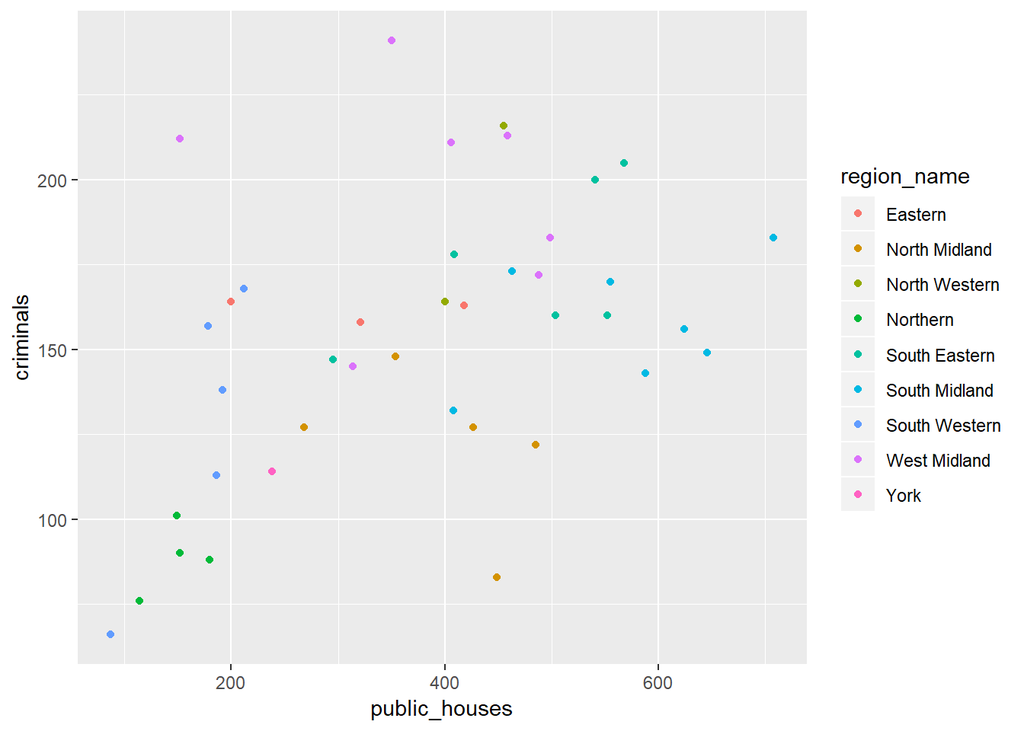

```r
crime %>% ggplot(aes(x=public_houses, y=criminals, color=region_name)) + geom_point()
```

Use dplyr to figure out how many counties are in this dataset, and which variable names map onto the independent and dependent variables you identified above.

```r
crime %>% distinct(county) %>% count()
```

```
## # A tibble: 1 x 1
##       n
##   <int>
## 1    40
```

Use select to select only the independent and dependent variables you identified above, then pipe those variables to the skim function from the skimr package (you should have loaded this package at the top) to see summary statistics for each. Use dplyr::summarize to calculate the correlation coefficient.

```r
crime %>% select(criminals, public_houses) %>% skim()
```

```
## Skim summary statistics
##  n obs: 40
##  n variables: 2
##
## -- Variable type:integer -----------------------------------------------------------------------
##       variable missing complete  n   mean     sd p0 p25   p50    p75 p100
##      criminals       0       40 40 152.9   41.42 66 127 157.5 174.25  241
##  public_houses       0       40 40 374.85 164.97 87 209 407   490.75  708
##      hist
##  ▂▂▃▅▇▂▃▁
##  ▃▆▂▂▇▅▃▂
```

Recreate the scatterplot below of ale/beer houses per 100K on the x-axis and criminals per 100K population on the y-axis. What can you say about the relationship between public houses and criminals based on this exploration?

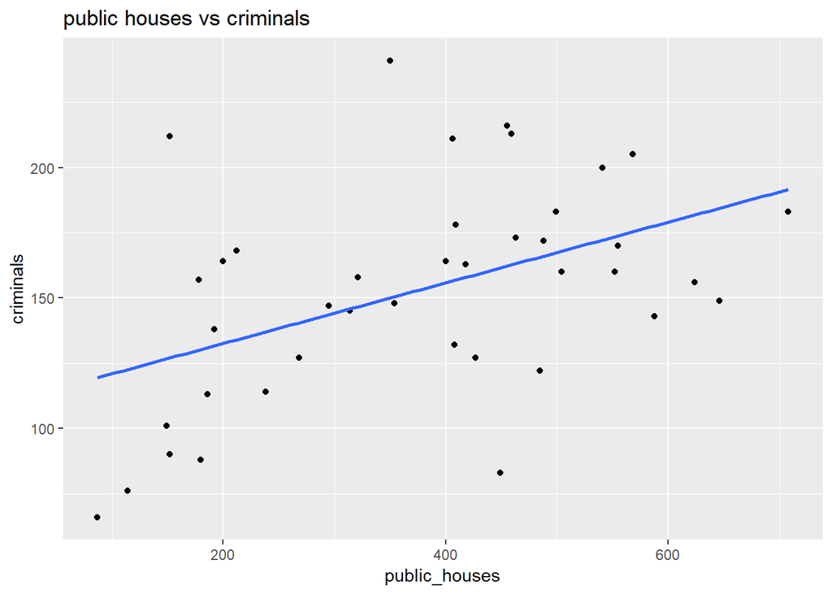

```r
crime %>% ggplot(aes(x=public_houses, y = criminals)) + geom_point() + ggtitle("public houses vs criminals") + geom_smooth(method='lm', se=FALSE)
```

```r
crime %>% summarize(crime_cor_coef = cor(criminals,public_houses))
```

```
## # A tibble: 1 x 1
##   crime_cor_coef
##            <dbl>
## 1          0.463
```

Props to Chris Klocke for helping me find the .dat file.